# Milk Drinking and Risk of Stroke Mortality

## Background and Objective

- **Tripeptide, calcium, and other functional nutrients in milk were believed to have anithypertensive effect.**
- **Stroke mortality was the No.4 leading cause of death in 2014 Japan's ranking of death rate.**
- **Diary food pattern and calcium intake were reported to be negatively associated with stroke mortality in the JACC study.**
- **Drinking milk reduced the risk of total mortality in the JACC study. Conflict results from other populations have drawn great attention on this issue.**
- **We aimed to compare the risk of stroke mortality between milk drinkers and non-drinkers in our cohort.**

## Method (1): Subjects

- Baseline: between 1988-1990;  
  n = 110,585  
  (46,395 men and 64190 women).
- Subjects with history of cancer, stroke, cardiovascular diseases, or those with missing information of the milk drinking habit were excluded from the analysis.  
  (n = 15,605)

[figure not shown]

## Method (2): Propensity Score Matching and Survival Analysis

- Propensity Score Matching (PSM): Nearest neighbor matching without replacement

```
Age, body mass index, smoking, drinking, exercise, sleep duration,
green-leafy vegetable intake, physical health checkup participation,
college or higher education, history of hypertension, diabetes,
liver dieseases were included as the covariates

Packages of "Matching" and "tableone" were used
```

- Survival analysis: Cox-proportional Hazard Models

## Absolute Standardized Differences in Men

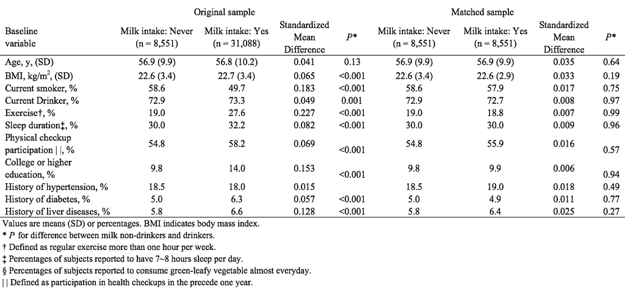

## Absolute Standardized Differences in Women

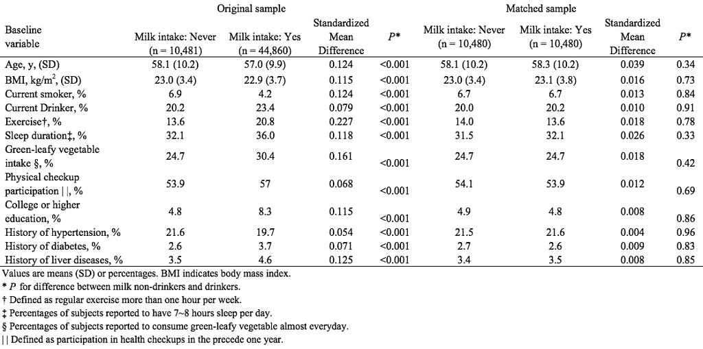

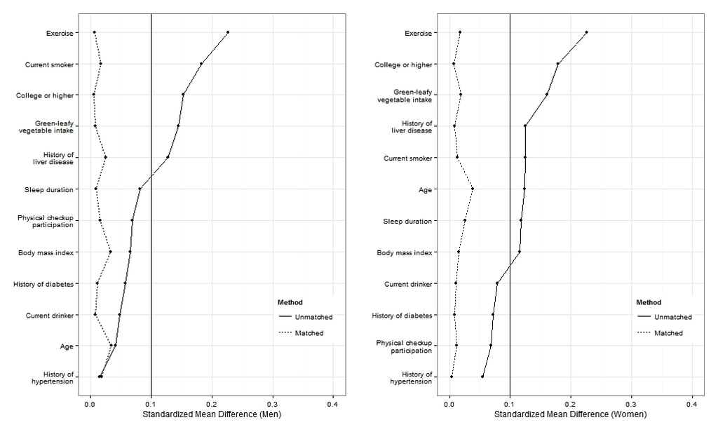

picture of Standardized mean difference

## Result: Hazard Ratios (95% CIs) of the Milk Drinkers against Non-drinkers

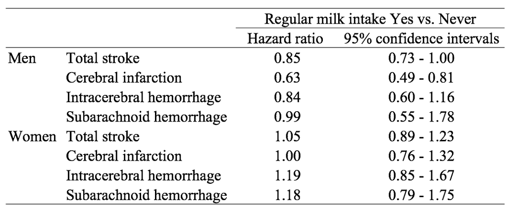

## Discussion & Conclusions

- We found reduced risk of death from total stroke and cerebral infarction in milk drinker only in men.
- Although the the baseline differences between milk drinkers and non-drinkers were balanced, information on milk intake and other potential confounders were collected only at baseline.
- The change of lifestyles during the follow-up may also lead to residual confounding.
- Drinking milk more than once a month was associated with lower risk of mortality from total stroke and cerebral infarction among Japanese men.